# Assignment 3:

#### Imports:

1. library(dplyr) # data wrangling
2. library(ggplot2) # visualization
3. library(tidyverse) # tidyverse
4. library(tibble) # tibble
5. library(tsibble) # tsibble
6. library(knitr) # knitr to display table
7. library(DataExplorer) # data explorer
8. library(lubridate) # lubridate
9. library(GGally) # GGally

#### Importing dataset:

```r
#set working directory to pull data

setwd("C:/Users/Titan/Desktop/UVA/UVA_AA_Semesters/UVA_Spring2022/SYS5581_TimeSeries/TimeSeries_Datasets/Mullick-Tahsin/MHEALTHDATASET/")


# Read data in as a tidy dataframe
df <- read.table("subject10.txt", sep="")
```

Previously we converted our data into a tidy dataset and then performed some brief exploration of subject 10’s data. In particular we looked at the variation of acceleration due to the chest based sensor on the z axis grouped by activity.

In this assignment we will further dive deeper into the datasets characteristics in particular will look at the data from subject 10 and investigate how the sensor behave over time.

#### Organize into Tidy data

```r
# setting column names for the data file based on the datasource

colnames(df) <- c('acc_chest_X','acc_chest_Y','acc_chest_Z','ecg_L1','ecg_l2','acc_leftankle_X',
                  'acc_leftankle_Y','acc_leftankle_Z','gyro_leftankle_X','gyro_leftankle_Y',
                  'gyro_leftankle_Z','mag_leftankle_X','mag_leftankle_Y','mag_leftankle_Z',
                  'acc_rlarm_X','acc_rlarm_Y','acc_rlarm_Z','gyro_rlarm_X','gyro_rlarm_Y',
                  'gyro_rlarm_Z','mag_rlarm_X','mag_rlarm_Y','mag_rlarm_Z','activity')
```

#### Looking at the head of the dataset to ensure dataset structure as per Tidy data

```r
#View(head(df,n=10))

knitr::kable(df[1:5,1:5],"pipe" , caption = "Subject 10 Activity Sensor Data")
```

Subject 10 Activity Sensor Data

| acc_chest_X | acc_chest_Y | acc_chest_Z | ecg_L1 | ecg_l2 |
| --- | --- | --- | --- | --- |
| -9.6997 | -0.87525 | -0.96298 | -0.029304 | -0.079540 |
| -9.4890 | -0.80103 | -1.10370 | -0.062794 | -0.092098 |
| -9.5541 | -1.08310 | -1.24480 | -0.075353 | -0.117220 |
| -9.3680 | -0.79141 | -0.93438 | -0.092098 | -0.129770 |
| -9.6678 | -0.95335 | -1.20160 | -0.092098 | -0.129770 |

#### Inspcting variables and there types in the dataframe

```r
str(df)
```

```
## 'data.frame':    98304 obs. of  24 variables:
##  $ acc_chest_X     : num  -9.7 -9.49 -9.55 -9.37 -9.67 ...
##  $ acc_chest_Y     : num  -0.875 -0.801 -1.083 -0.791 -0.953 ...
##  $ acc_chest_Z     : num  -0.963 -1.104 -1.245 -0.934 -1.202 ...
##  $ ecg_L1          : num  -0.0293 -0.0628 -0.0754 -0.0921 -0.0921 ...
##  $ ecg_l2          : num  -0.0795 -0.0921 -0.1172 -0.1298 -0.1298 ...
##  $ acc_leftankle_X : num  0.284 0.418 0.335 0.275 0.324 ...
##  $ acc_leftankle_Y : num  -9.57 -9.7 -9.59 -9.65 -9.63 ...
##  $ acc_leftankle_Z : num  1.49 1.49 1.44 1.54 1.38 ...
##  $ gyro_leftankle_X: num  0.705 0.705 0.694 0.694 0.694 ...
##  $ gyro_leftankle_Y: num  -0.49 -0.49 -0.486 -0.486 -0.486 ...
##  $ gyro_leftankle_Z: num  0.0589 0.0589 0.0786 0.0786 0.0786 ...
##  $ mag_leftankle_X : num  0.194 0.37 0.37 0.379 0.37 ...
##  $ mag_leftankle_Y : num  0.365 0.547 0.547 0.73 0.547 ...
##  $ mag_leftankle_Z : num  -0.44 -0.301 -0.301 -0.592 -0.301 ...
##  $ acc_rlarm_X     : num  -0.986 -0.988 -0.893 -0.956 -0.958 ...
##  $ acc_rlarm_Y     : num  -8.72 -9.04 -8.71 -8.8 -8.51 ...
##  $ acc_rlarm_Z     : num  4.12 4.28 4.01 4.14 4.11 ...
##  $ gyro_rlarm_X    : num  0.645 0.667 0.667 0.667 0.669 ...
##  $ gyro_rlarm_Y    : num  -0.452 -0.444 -0.444 -0.444 -0.452 ...
##  $ gyro_rlarm_Z    : num  0.692 0.668 0.668 0.668 0.692 ...
##  $ mag_rlarm_X     : num  0.72 0.54 0.725 0.544 0.542 ...
##  $ mag_rlarm_Y     : num  0.178 0.18 0.726 0.532 0.35 ...
##  $ mag_rlarm_Z     : num  0.374 0.37 0.729 -0.716 -0.715 ...
##  $ activity        : int  0 0 0 0 0 0 0 0 0 0 ...
```

#### Converting the ‘activity’ column into type-factor:

```r
df[,'activity']<-factor(df[,'activity'])
typeof(df$activity)
```

```
## [1] "integer"
```

```r
class(df$activity)
```

```
## [1] "factor"
```

#### Observing activity class distribution

The activity are labeled from 1 to 12 and are listed below as follows:

1. L1: Standing still (1 min)
2. L2: Sitting and relaxing (1 min)
3. L3: Lying down (1 min)
4. L4: Walking (1 min)
5. L5: Climbing stairs (1 min)
6. L6: Waist bends forward (20x)
7. L7: Frontal elevation of arms (20x)
8. L8: Knees bending (crouching) (20x)
9. L9: Cycling (1 min)
10. L10: Jogging (1 min)
11. L11: Running (1 min)
12. L12: Jump front & back (20x)

```r
summary(df$activity)
```

```
##     0     1     2     3     4     5     6     7     8     9    10    11    12
## 64614  3072  3072  3072  3072  3072  2458  2765  2867  3072  3072  3072  1024
```

#### Creating datetime column following the dataset guide line for 50Hz rate of sensor readings i.e. 0.02 sec interval between sensor readings

```r
df$date_time <- Sys.time()+0.02 * (seq_len(nrow(df))-1)
```

#### Checking the dataset to ensure datetime column was added:

```r
#View(head(df,n=10))

knitr::kable(df[1:5,22:25],"pipe" , caption = "Subject 10 Activity Sensor Data")
```

Subject 10 Activity Sensor Data

| mag_rlarm_Y | mag_rlarm_Z | activity | date_time |
| --- | --- | --- | --- |
| 0.17803 | 0.37363 | 0 | 2022-05-09 12:52:00 |
| 0.17978 | 0.37002 | 0 | 2022-05-09 12:52:00 |
| 0.72599 | 0.72927 | 0 | 2022-05-09 12:52:00 |
| 0.53186 | -0.71646 | 0 | 2022-05-09 12:52:00 |
| 0.35041 | -0.71468 | 0 | 2022-05-09 12:52:00 |

#### Summary of the data

```r
summary(df)
```

```
##   acc_chest_X       acc_chest_Y         acc_chest_Z          ecg_L1
##  Min.   :-22.139   Min.   :-19.95800   Min.   :-17.788   Min.   :-1.913100
##  1st Qu.: -9.758   1st Qu.: -0.80287   1st Qu.: -4.081   1st Qu.:-0.154890
##  Median : -9.175   Median : -0.08434   Median : -2.218   Median :-0.075353
##  Mean   : -8.417   Mean   :  0.20093   Mean   : -2.667   Mean   :-0.004872
##  3rd Qu.: -6.629   3rd Qu.:  1.07980   3rd Qu.: -1.460   3rd Qu.: 0.037677
##  Max.   : 17.618   Max.   : 17.86900   Max.   :  7.547   Max.   : 3.503900
##
##      ecg_l2           acc_leftankle_X    acc_leftankle_Y   acc_leftankle_Z
##  Min.   :-1.6159000   Min.   :-22.0620   Min.   :-19.599   Min.   :-19.36400
##  1st Qu.:-0.1214000   1st Qu.: -0.1843   1st Qu.:-10.753   1st Qu.: -3.03892
##  Median :-0.0544220   Median :  0.6592   Median : -9.770   Median : -0.04887
##  Mean   : 0.0003576   Mean   :  1.2650   Mean   : -9.931   Mean   : -1.22256
##  3rd Qu.: 0.0418630   3rd Qu.:  2.1164   3rd Qu.: -9.006   3rd Qu.:  1.07920
##  Max.   : 2.7713000   Max.   : 20.0140   Max.   : 20.766   Max.   : 24.40000
##
##  gyro_leftankle_X   gyro_leftankle_Y  gyro_leftankle_Z   mag_leftankle_X
##  Min.   :-1.58630   Min.   :-3.0919   Min.   :-2.19840   Min.   :-348.8300
##  1st Qu.:-0.33024   1st Qu.:-0.8518   1st Qu.:-0.72888   1st Qu.: -28.2820
##  Median : 0.11132   Median :-0.7336   Median :-0.53831   Median :  -0.1588
##  Mean   : 0.05607   Mean   :-0.6213   Mean   :-0.38233   Mean   :   0.3748
##  3rd Qu.: 0.47681   3rd Qu.:-0.4953   3rd Qu.:-0.05108   3rd Qu.:   3.6065
##  Max.   : 1.57880   Max.   : 1.6473   Max.   : 1.82120   Max.   : 335.1600
##
##  mag_leftankle_Y     mag_leftankle_Z      acc_rlarm_X       acc_rlarm_Y
##  Min.   :-364.4400   Min.   :-203.5500   Min.   :-21.825   Min.   :-18.863
##  1st Qu.:  -9.1969   1st Qu.:  -3.9301   1st Qu.: -5.922   1st Qu.: -9.647
##  Median :   0.5448   Median :  -0.4459   Median : -3.321   Median : -8.247
##  Mean   :  -1.5662   Mean   :  -0.8653   Mean   : -4.144   Mean   : -7.060
##  3rd Qu.:   6.2921   3rd Qu.:   2.6570   3rd Qu.: -2.013   3rd Qu.: -4.292
##  Max.   : 335.9700   Max.   : 151.3300   Max.   : 19.398   Max.   : 16.432
##
##   acc_rlarm_Z        gyro_rlarm_X      gyro_rlarm_Y      gyro_rlarm_Z
##  Min.   :-17.8760   Min.   :-1.3902   Min.   :-2.0780   Min.   :-1.47200
##  1st Qu.: -1.0027   1st Qu.:-0.6196   1st Qu.:-0.9836   1st Qu.:-0.48707
##  Median :  0.1226   Median :-0.1529   Median :-0.7762   Median : 0.14224
##  Mean   :  0.8197   Mean   :-0.1700   Mean   :-0.6753   Mean   : 0.06174
##  3rd Qu.:  1.8964   3rd Qu.: 0.2784   3rd Qu.:-0.4764   3rd Qu.: 0.53448
##  Max.   : 22.0800   Max.   : 1.1373   Max.   : 1.1006   Max.   : 1.44610
##
##   mag_rlarm_X         mag_rlarm_Y         mag_rlarm_Z           activity
##  Min.   :-143.6500   Min.   :-264.3400   Min.   :-504.8000   0      :64614
##  1st Qu.:  -6.1407   1st Qu.:  -9.8872   1st Qu.: -15.2573   1      : 3072
##  Median :   0.3590   Median :   0.3522   Median :  -0.7147   2      : 3072
##  Mean   :  -0.0484   Mean   :   0.5334   Mean   :  -0.8404   3      : 3072
##  3rd Qu.:   6.7591   3rd Qu.:  10.1355   3rd Qu.:  14.1325   4      : 3072
##  Max.   : 141.7300   Max.   : 332.0600   Max.   : 616.9300   5      : 3072
##                                                              (Other):18330
##    date_time
##  Min.   :2022-05-09 12:52:00
##  1st Qu.:2022-05-09 13:00:11
##  Median :2022-05-09 13:08:23
##  Mean   :2022-05-09 13:08:23
##  3rd Qu.:2022-05-09 13:16:34
##  Max.   :2022-05-09 13:24:46
##
```

#### Converting dataframe to tibble object

```r
df %>% as_tibble(df)-> df_tbl
```

#### New code block to convert to tsibble followed by key and index assignment

```r
typeof(df_tbl)
```

```
## [1] "list"
```

```r
class(df_tbl)
```

```
## [1] "tbl_df"     "tbl"        "data.frame"
```

```r
df_tbl %>% as_tsibble(index = date_time) -> df_tbl_ts1
```

```r
#old code
df_tbl %>%
  as_tsibble(key = c(acc_chest_X, acc_chest_Y, acc_chest_Z,
                     ecg_L1,ecg_l2,acc_leftankle_X,acc_leftankle_Y,acc_leftankle_Z,
                     gyro_leftankle_X,gyro_leftankle_Y,gyro_leftankle_Z,
                     mag_leftankle_X,mag_leftankle_Y,mag_leftankle_Z,
                     acc_rlarm_X,acc_rlarm_Y,acc_rlarm_Z,
                     gyro_rlarm_X,gyro_rlarm_Y,gyro_rlarm_Z,
                     mag_rlarm_X,mag_rlarm_Y,mag_rlarm_Z,activity) ,
             index = date_time) -> df_tbl_ts1
```

#### checking to see the type of df_tbl_ts to ensure it is a tsibble object

```r
typeof(df_tbl_ts1)
```

```
## [1] "list"
```

```r
class(df_tbl_ts1)
```

```
## [1] "tbl_ts"     "tbl_df"     "tbl"        "data.frame"
```

```r
print(df_tbl_ts1[1:5, 20:25])
```

```
## # A tsibble: 5 x 6 [0.0149016727846174us] <?>
## # Key:       gyro_rlarm_Z, mag_rlarm_X, mag_rlarm_Y, mag_rlarm_Z, activity [5]
##   gyro_rlarm_Z mag_rlarm_X mag_rlarm_Y mag_rlarm_Z activity date_time
##          <dbl>       <dbl>       <dbl>       <dbl> <fct>    <dttm>
## 1        0.791       -15.6      36.7          65.0 0        2022-05-09 13:19:07
## 2        0.866       -20.6     -10.7          51.3 11       2022-05-09 13:20:08
## 3        0.976        66.8     -16.8        -321.  11       2022-05-09 13:19:24
## 4        1.06         37.3      -0.910      -344.  11       2022-05-09 13:20:02
## 5        0.884        63.0     -15.0        -257.  11       2022-05-09 13:19:56
```

#### Resent order of the tsibble object

Even though we have set the index as date time the previous operation of adding a column causes the sequence to be disordered as such we perform a sorting to sort our date time in increasing order

```r
#Ensuring that the datetime is sorted in increasing order

df_tbl_ts1 %>% arrange(ymd_hms(df_tbl_ts1$date_time)) -> df_tbl_ts1_srtd
```

```r
# checking the sorted tsibble
print(df_tbl_ts1_srtd[1:10, 20:25])
```

```
## # A tsibble: 10 x 6 [0.0149016727846174us] <?>
## # Key:       gyro_rlarm_Z, mag_rlarm_X, mag_rlarm_Y, mag_rlarm_Z, activity [10]
##    gyro_rlarm_Z mag_rlarm_X mag_rlarm_Y mag_rlarm_Z activity date_time
##           <dbl>       <dbl>       <dbl>       <dbl> <fct>    <dttm>
##  1        0.681      -0.401      -4.16       0.756  0        2022-05-09 12:52:00
##  2        0.683       1.08        0.712     -0.346  0        2022-05-09 12:52:00
##  3        0.675       1.27        1.26       0.0128 0        2022-05-09 12:52:00
##  4        0.703       0.548       0.891     -1.08   0        2022-05-09 12:52:00
##  5        0.683       0.158      -2.18       0.0249 0        2022-05-09 12:52:00
##  6        0.683       0.892      -0.560     -0.699  0        2022-05-09 12:52:00
##  7        0.705       0.546       0.710     -1.08   0        2022-05-09 12:52:00
##  8        0.681      -0.390      -3.07       0.745  0        2022-05-09 12:52:00
##  9        0.690       0.537      -0.194     -0.709  0        2022-05-09 12:52:00
## 10        0.679       0.350      -0.922     -1.07   0        2022-05-09 12:52:00
```

#### Now that we have our tsibble data object we conduct a primary analysis of the frequency of each class of activity

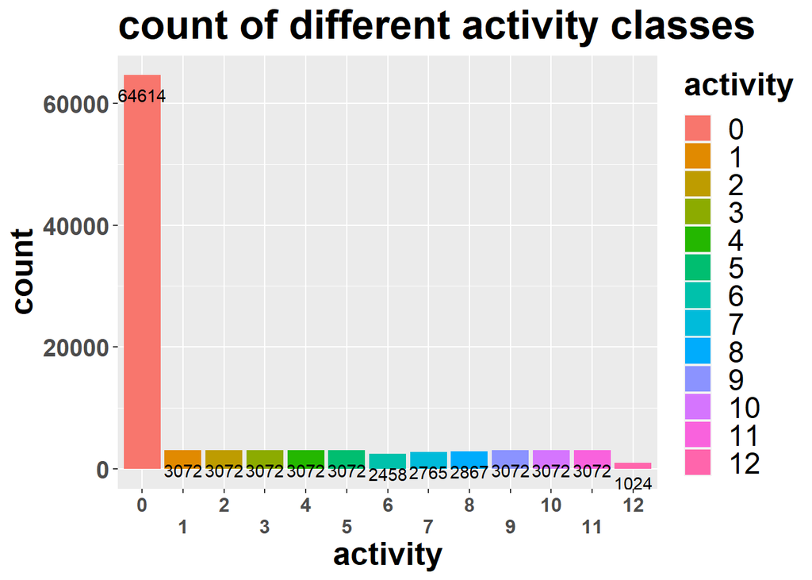

```r
ggplot(df_tbl_ts1_srtd,aes(x= activity, fill = activity))+
  geom_bar() +
  geom_text(stat = 'count', aes(label=..count..), vjust=2)+
  scale_x_discrete(guide = guide_axis(n.dodge = 2)) +
  labs(title="count of different activity classes") +
  theme(plot.title = element_text(size = 25, face = "bold"),
        legend.title = element_text(size=20, face = "bold"),
        legend.text = element_text(size=18),
        axis.text.x = element_text(size = 12, face = "bold"),
        axis.text.y = element_text(size = 15, face = "bold"),
        axis.title = element_text(size = 20, face = "bold"))
```

We observe that there is some imbalance in the data in particular this imbalance is due to the null activity class. This will be dealt with in the modeling assignment. Where my plan is to apply re-sampling technique to undersample the majority activity class (“NULL”)

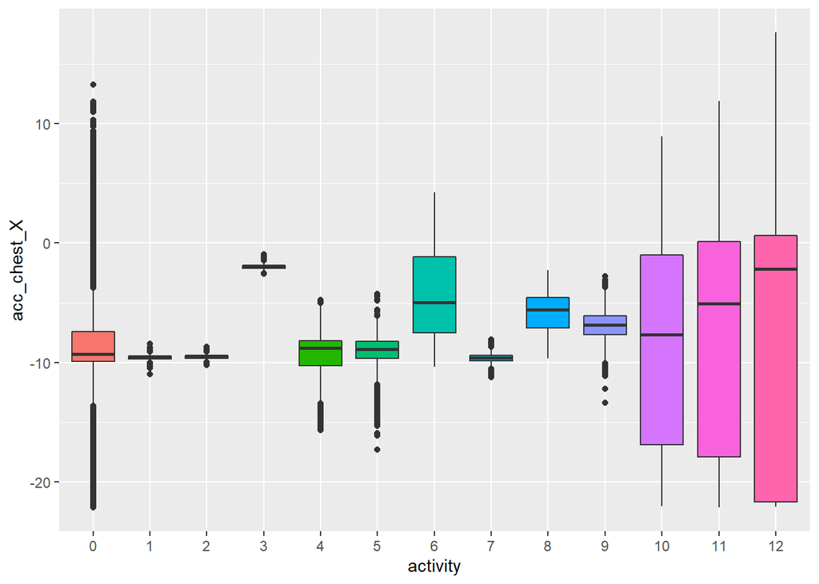

```r
acc_box_plot <- ggplot(df_tbl_ts1_srtd,
       aes(y=acc_chest_X, x = activity, group = activity,fill = activity )) +
  geom_boxplot(show.legend = FALSE)

#acc_box_plot + scale_fill_hue(l=20,c=20)
acc_box_plot
```

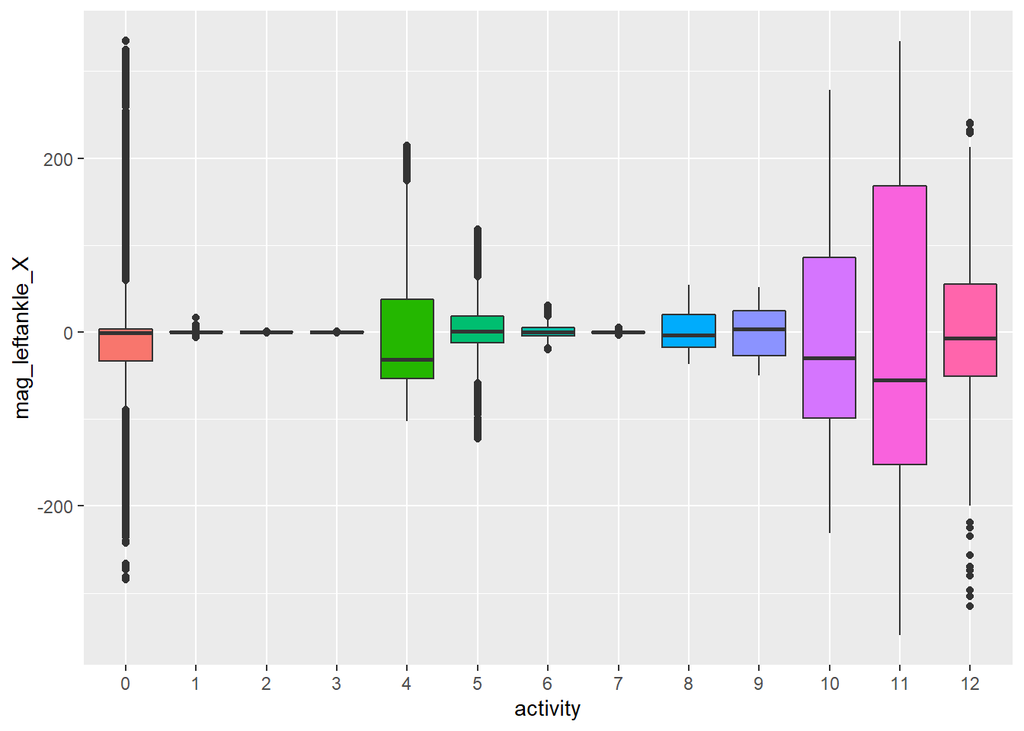

```r
mag_box_plot <- ggplot(df_tbl_ts1_srtd,
       aes(y= mag_leftankle_X, x = activity, group = activity,fill = activity )) +
  geom_boxplot(show.legend = FALSE)
mag_box_plot
```

We observe that a difference is distinguishable in the activites that invovle movement from those that are stationary.

- The distinction is prominent in case of magnetometer and accelerometer readings
- Therefore these sensors can definitely play an important role in time series based classification

#### In order to have labels for further plotting along with the ordinal representation of the activity classes I will introduce a column of the activity definitions

```r
df_tbl_ts1_srtd %>%
  mutate(activity_label = case_when(
    activity == 0~"Null",
    activity == 1~"Standing",
    activity == 2~"Sitting",
    activity == 3~"Lying down",
    activity == 4~"Walking",
    activity == 5~"Climbing_Stairs",
    activity == 6~"Waist_Bends_Forward",
    activity == 7~"Elevating_Arms",
    activity == 8~"Crounching",
    activity == 9~"Cycling",
    activity == 10~"Jogging",
    activity == 11~"Running",
    activity == 12~"Jump"
  )) -> df_tbl_ts1_lbld
```

```r
print(df_tbl_ts1_lbld[1:10, 20:26])
```

```
## # A tsibble: 10 x 7 [0.0149016727846174us] <?>
## # Key:       gyro_rlarm_Z, mag_rlarm_X, mag_rlarm_Y, mag_rlarm_Z, activity [10]
##    gyro_rlarm_Z mag_rlarm_X mag_rlarm_Y mag_rlarm_Z activity date_time
##           <dbl>       <dbl>       <dbl>       <dbl> <fct>    <dttm>
##  1        0.681      -0.401      -4.16       0.756  0        2022-05-09 12:52:00
##  2        0.683       1.08        0.712     -0.346  0        2022-05-09 12:52:00
##  3        0.675       1.27        1.26       0.0128 0        2022-05-09 12:52:00
##  4        0.703       0.548       0.891     -1.08   0        2022-05-09 12:52:00
##  5        0.683       0.158      -2.18       0.0249 0        2022-05-09 12:52:00
##  6        0.683       0.892      -0.560     -0.699  0        2022-05-09 12:52:00
##  7        0.705       0.546       0.710     -1.08   0        2022-05-09 12:52:00
##  8        0.681      -0.390      -3.07       0.745  0        2022-05-09 12:52:00
##  9        0.690       0.537      -0.194     -0.709  0        2022-05-09 12:52:00
## 10        0.679       0.350      -0.922     -1.07   0        2022-05-09 12:52:00
## # ... with 1 more variable: activity_label <chr>
```

```r
# Drop null (0) class  activity rows:

df_tbl_ts2 <- subset(df_tbl_ts1_lbld, activity_label != "Null")
```

#### plot to evaluate the classes after null class has been removed

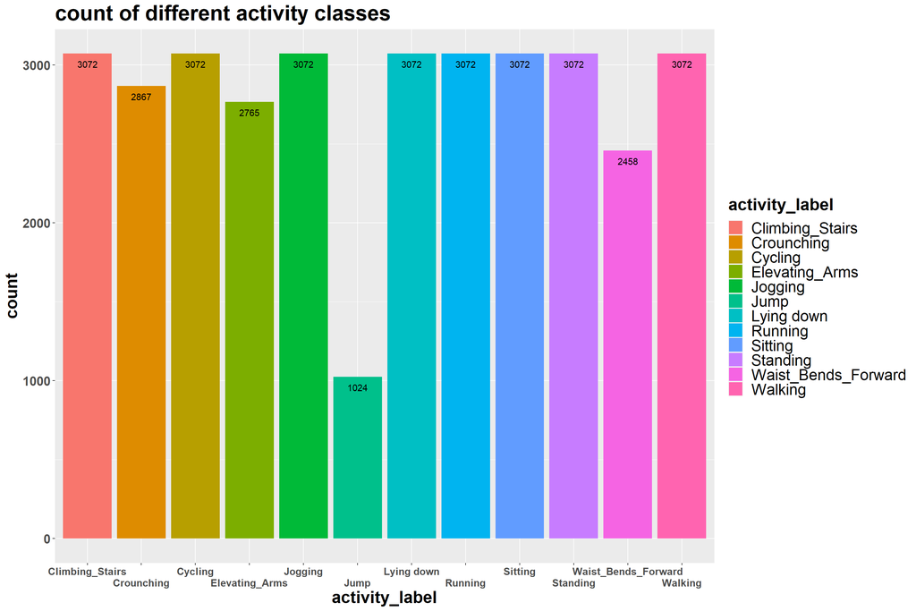

```r
ggplot(df_tbl_ts2,aes(x= activity_label, fill = activity_label))+
  geom_bar() +
  geom_text(stat = 'count', aes(label=..count..), vjust=2)+
  scale_x_discrete(guide = guide_axis(n.dodge = 2)) +
  labs(title="count of different activity classes") +
  theme(plot.title = element_text(size = 25, face = "bold"),
        legend.title = element_text(size=20, face = "bold"),
        legend.text = element_text(size=18),
        axis.text.x = element_text(size = 12, face = "bold"),
        axis.text.y = element_text(size = 15, face = "bold"),
        axis.title = element_text(size = 20, face = "bold"))
```

We verify in this observation that the other classes are not highly imbalanced.

#### We now try to visualize the data in a lower dimension with the help of T-SNE to find how much overlap there exists between classes

```r
library(Rtsne)
```

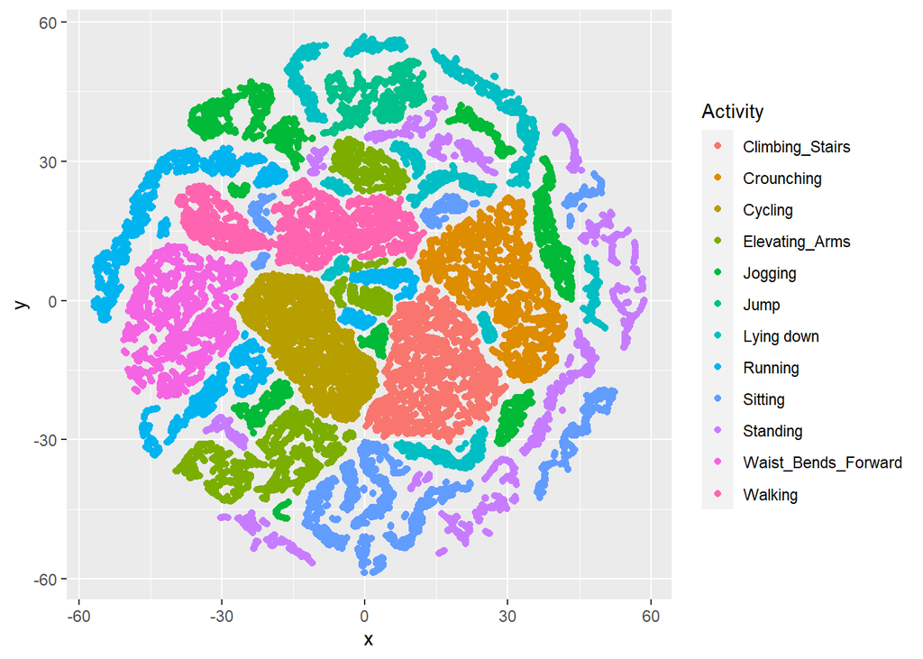

```r
for (perp in c(10)) {
  tsne <- Rtsne(df_tbl_ts2 %>% select(-c(activity, activity_label)), perplexity = perp)
  tsne_plot <- data.frame(x = tsne$Y[,1], y = tsne$Y[,2], Activity = df_tbl_ts2$activity_label)
  print(
    ggplot(tsne_plot) +
      geom_point(aes(x = x, y = y, color = Activity))
  )
}
```

#### The plot above reveals that the data from a high dimensional perspective has activity classes that can be distinguishable. Some classes such as standing and sitting and jump and jogging are very close to each other. This does make sense as these activities often are close in terms of gyroscopic as well as acceleration based features.

#### Next let us look at a subset of a stationary activity Vs mobility driven activity to get a sense of their sensor readings

```r
df_tbl_ts2 %>% filter(activity_label=="Standing")->df_tbl_standing
print(df_tbl_standing[1:10])
```

```
## # A tibble: 3,072 x 10
##    acc_chest_X acc_chest_Y acc_chest_Z  ecg_L1  ecg_l2 acc_leftankle_X
##          <dbl>       <dbl>       <dbl>   <dbl>   <dbl>           <dbl>
##  1      -10.1      -0.227        -1.46 -0.188  -0.134          0.311
##  2       -9.82     -0.232        -1.82  0.0419  0.0419         0.354
##  3       -9.78     -0.170        -1.87 -0.100  -0.0712         0.345
##  4       -9.74     -0.204        -1.47 -0.0795 -0.0502        -0.00339
##  5       -9.74     -0.0104       -1.62 -0.142  -0.0837         0.374
##  6       -9.71      0.283        -1.64 -0.0460 -0.0167         0.332
##  7       -9.69     -0.264        -1.48 -0.167  -0.130          0.324
##  8       -9.69     -0.523        -1.80  1.32    1.06           0.201
##  9       -9.68     -0.0689       -1.77 -0.126  -0.0712         0.262
## 10       -9.67     -0.152        -1.53 -0.0837 -0.0460         0.414
## # ... with 3,062 more rows, and 4 more variables: acc_leftankle_Y <dbl>,
## #   acc_leftankle_Z <dbl>, gyro_leftankle_X <dbl>, gyro_leftankle_Y <dbl>
```

```r
summary(df_tbl_standing)
```

```
##   acc_chest_X       acc_chest_Y         acc_chest_Z          ecg_L1
##  Min.   :-10.951   Min.   :-1.026300   Min.   :-2.6547   Min.   :-0.925170
##  1st Qu.: -9.681   1st Qu.:-0.248650   1st Qu.:-1.7959   1st Qu.:-0.117220
##  Median : -9.572   Median :-0.121045   Median :-1.6639   Median :-0.079540
##  Mean   : -9.569   Mean   :-0.120960   Mean   :-1.6701   Mean   :-0.006801
##  3rd Qu.: -9.455   3rd Qu.: 0.003348   3rd Qu.:-1.5455   3rd Qu.:-0.016745
##  Max.   : -8.419   Max.   : 0.836760   Max.   :-0.8156   Max.   : 2.892700
##
##      ecg_l2           acc_leftankle_X   acc_leftankle_Y   acc_leftankle_Z
##  Min.   :-0.7870200   Min.   :-0.2758   Min.   :-10.565   Min.   :0.6150
##  1st Qu.:-0.0879120   1st Qu.: 0.2321   1st Qu.: -9.829   1st Qu.:0.9863
##  Median :-0.0502350   Median : 0.3113   Median : -9.752   Median :1.0821
##  Mean   : 0.0006541   Mean   : 0.3140   Mean   : -9.749   Mean   :1.0950
##  3rd Qu.: 0.0000000   3rd Qu.: 0.3854   3rd Qu.: -9.673   3rd Qu.:1.1817
##  Max.   : 2.1685000   Max.   : 0.9695   Max.   : -8.880   Max.   :2.9392
##
##  gyro_leftankle_X   gyro_leftankle_Y  gyro_leftankle_Z mag_leftankle_X
##  Min.   :-0.20779   Min.   :-0.7411   Min.   :0.6228   Min.   :-6.00080
##  1st Qu.:-0.18367   1st Qu.:-0.7167   1st Qu.:0.6503   1st Qu.: 0.01744
##  Median :-0.17440   Median :-0.7092   Median :0.6582   Median : 0.20691
##  Mean   :-0.17290   Mean   :-0.7083   Mean   :0.6599   Mean   : 0.26800
##  3rd Qu.:-0.16512   3rd Qu.:-0.7017   3rd Qu.:0.6660   3rd Qu.: 0.55067
##  Max.   :-0.06679   Max.   :-0.6473   Max.   :0.7230   Max.   :16.40000
##
##  mag_leftankle_Y    mag_leftankle_Z    acc_rlarm_X      acc_rlarm_Y
##  Min.   :-24.0170   Min.   :-5.1383   Min.   :-3.586   Min.   :-10.294
##  1st Qu.:  0.3650   1st Qu.:-0.5865   1st Qu.:-2.743   1st Qu.: -9.532
##  Median :  0.5468   Median :-0.4441   Median :-2.636   Median : -9.452
##  Mean   :  0.5410   Mean   :-0.4486   Mean   :-2.635   Mean   : -9.451
##  3rd Qu.:  0.7302   3rd Qu.:-0.3032   3rd Qu.:-2.527   3rd Qu.: -9.373
##  Max.   : 11.7940   Max.   : 1.8728   Max.   :-1.414   Max.   : -8.998
##
##   acc_rlarm_Z       gyro_rlarm_X      gyro_rlarm_Y      gyro_rlarm_Z
##  Min.   :-1.2722   Min.   :-0.9078   Min.   :-0.6940   Min.   :0.09052
##  1st Qu.:-0.3924   1st Qu.:-0.8686   1st Qu.:-0.6550   1st Qu.:0.16164
##  Median :-0.2883   Median :-0.8608   Median :-0.6468   Median :0.17888
##  Mean   :-0.2801   Mean   :-0.8597   Mean   :-0.6472   Mean   :0.18561
##  3rd Qu.:-0.1804   3rd Qu.:-0.8529   3rd Qu.:-0.6386   3rd Qu.:0.19828
##  Max.   : 0.5582   Max.   :-0.7922   Max.   :-0.5975   Max.   :0.32328
##
##   mag_rlarm_X       mag_rlarm_Y        mag_rlarm_Z           activity
##  Min.   :-6.2748   Min.   :-20.4930   Min.   :-9.026000   1      :3072
##  1st Qu.: 0.1758   1st Qu.: -0.1922   1st Qu.:-1.072100   0      :   0
##  Median : 0.3627   Median :  0.3523   Median :-0.703960   2      :   0
##  Mean   : 0.3567   Mean   :  0.3033   Mean   :-0.555748   3      :   0
##  3rd Qu.: 0.5494   3rd Qu.:  0.9001   3rd Qu.: 0.000154   4      :   0
##  Max.   : 5.4840   Max.   : 12.3310   Max.   : 6.884800   5      :   0
##                                                           (Other):   0
##    date_time                   activity_label
##  Min.   :2022-05-09 13:02:14   Length:3072
##  1st Qu.:2022-05-09 13:02:29   Class :character
##  Median :2022-05-09 13:02:45   Mode  :character
##  Mean   :2022-05-09 13:02:45
##  3rd Qu.:2022-05-09 13:03:00
##  Max.   :2022-05-09 13:03:15
##
```

```r
df_tbl_ts2 %>% filter(activity_label=="Walking")->df_tbl_walking
summary(df_tbl_walking)
```

```
##   acc_chest_X       acc_chest_Y        acc_chest_Z           ecg_L1
##  Min.   :-15.676   Min.   :-2.98210   Min.   :-5.80000   Min.   :-1.159600
##  1st Qu.:-10.254   1st Qu.:-1.04852   1st Qu.:-3.18818   1st Qu.:-0.138150
##  Median : -8.802   Median :-0.59195   Median :-2.23340   Median :-0.083726
##  Mean   : -9.397   Mean   :-0.39143   Mean   :-2.40528   Mean   :-0.003491
##  3rd Qu.: -8.156   3rd Qu.: 0.01817   3rd Qu.:-1.60725   3rd Qu.: 0.016745
##  Max.   : -4.750   Max.   : 4.39070   Max.   : 0.05922   Max.   : 2.825700
##
##      ecg_l2          acc_leftankle_X    acc_leftankle_Y   acc_leftankle_Z
##  Min.   :-0.862380   Min.   :-16.1500   Min.   :-19.439   Min.   :-19.0560
##  1st Qu.:-0.104660   1st Qu.:  0.1113   1st Qu.:-13.531   1st Qu.: -2.3763
##  Median :-0.058608   Median :  1.4491   Median :-10.135   Median : -0.4879
##  Mean   :-0.001086   Mean   :  1.4899   Mean   :-11.080   Mean   : -1.3968
##  3rd Qu.: 0.012559   3rd Qu.:  2.7431   3rd Qu.: -8.966   3rd Qu.:  0.9624
##  Max.   : 2.243900   Max.   : 20.0130   Max.   :  1.138   Max.   : 23.2530
##
##  gyro_leftankle_X gyro_leftankle_Y  gyro_leftankle_Z  mag_leftankle_X
##  Min.   :0.2727   Min.   :-0.9531   Min.   :-0.4853   Min.   :-102.7500
##  1st Qu.:0.4341   1st Qu.:-0.8522   1st Qu.:-0.0668   1st Qu.: -53.5470
##  Median :0.5102   Median :-0.7054   Median : 0.3360   Median : -31.7985
##  Mean   :0.5042   Mean   :-0.6760   Mean   : 0.2299   Mean   :   0.1976
##  3rd Qu.:0.5696   3rd Qu.:-0.5178   3rd Qu.: 0.5363   3rd Qu.:  37.5423
##  Max.   :0.7180   Max.   :-0.2683   Max.   : 0.7289   Max.   : 214.9000
##
##  mag_leftankle_Y    mag_leftankle_Z     acc_rlarm_X      acc_rlarm_Y
##  Min.   :-190.190   Min.   :-46.3500   Min.   :-5.505   Min.   :-15.218
##  1st Qu.: -16.922   1st Qu.: -6.4385   1st Qu.:-3.791   1st Qu.:-10.107
##  Median :  -3.493   Median :  2.1154   Median :-3.196   Median : -8.681
##  Mean   :  -2.102   Mean   : -0.7621   Mean   :-3.080   Mean   : -9.284
##  3rd Qu.:  13.579   3rd Qu.:  7.6188   3rd Qu.:-2.460   3rd Qu.: -8.051
##  Max.   : 192.360   Max.   : 35.5050   Max.   : 1.735   Max.   : -6.013
##
##   acc_rlarm_Z        gyro_rlarm_X      gyro_rlarm_Y      gyro_rlarm_Z
##  Min.   :-1.36450   Min.   :-0.8745   Min.   :-0.7351   Min.   :0.2694
##  1st Qu.: 0.05398   1st Qu.:-0.6725   1st Qu.:-0.6673   1st Qu.:0.6315
##  Median : 0.52426   Median :-0.6353   Median :-0.6468   Median :0.6681
##  Mean   : 0.53738   Mean   :-0.6397   Mean   :-0.6450   Mean   :0.6568
##  3rd Qu.: 1.00330   3rd Qu.:-0.5980   3rd Qu.:-0.6263   3rd Qu.:0.6983
##  Max.   : 3.03980   Max.   :-0.4745   Max.   :-0.5154   Max.   :0.7996
##
##   mag_rlarm_X         mag_rlarm_Y        mag_rlarm_Z          activity
##  Min.   :-15.58100   Min.   :-54.4020   Min.   :-42.6590   4      :3072
##  1st Qu.: -2.96243   1st Qu.: -6.7263   1st Qu.:-10.6928   0      :   0
##  Median : -0.08757   Median : -0.3159   Median : -3.1601   1      :   0
##  Mean   :  0.26542   Mean   :  0.3713   Mean   : -0.7003   2      :   0
##  3rd Qu.:  3.02712   3rd Qu.:  7.3160   3rd Qu.:  6.8304   3      :   0
##  Max.   : 15.94800   Max.   : 51.0380   Max.   : 59.9330   5      :   0
##                                                            (Other):   0
##    date_time                   activity_label
##  Min.   :2022-05-09 13:06:50   Length:3072
##  1st Qu.:2022-05-09 13:07:06   Class :character
##  Median :2022-05-09 13:07:21   Mode  :character
##  Mean   :2022-05-09 13:07:21
##  3rd Qu.:2022-05-09 13:07:36
##  Max.   :2022-05-09 13:07:52
##
```

#### A time series visualization of selected sensors:

#### 1. magnetometer on arm

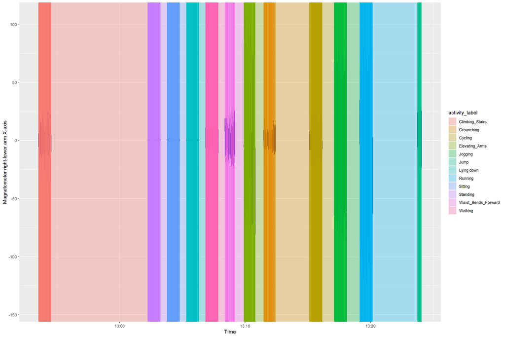

```r
#ggplot(df_tbl_ts2,aes(x= activity_label, fill = activity_label))
ggplot(data=df_tbl_ts2, aes(x=date_time,y= mag_rlarm_X, fill=activity_label))+
  geom_line(colour="#000099")+
  geom_rect( aes(xmin = date_time, xmax =dplyr::lead(date_time),ymin=-Inf,ymax=Inf), alpha=0.3)+
  xlab("Time")+ ylab("Magnetometer right-lower arm X-axis")
```

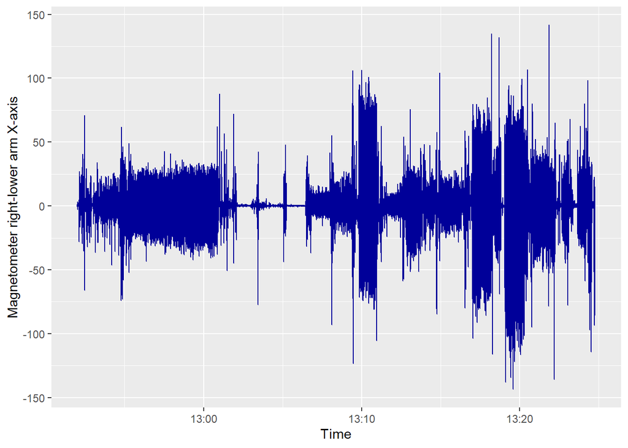

```r
ggplot(data=df_tbl_ts1_srtd, aes(x=date_time,y= mag_rlarm_X))+
  geom_line(colour="#000099")+
  xlab("Time")+ ylab("Magnetometer right-lower arm X-axis")
```

#### 2. acelerometer on arm

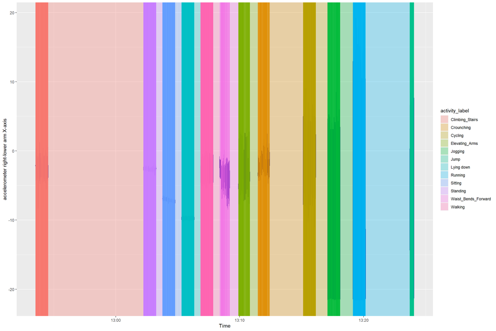

```r
ggplot(data=df_tbl_ts2, aes(x=date_time,y= acc_rlarm_X, fill=activity_label))+
  geom_line(colour="#000099")+
  geom_rect( aes(xmin = date_time, xmax =dplyr::lead(date_time),ymin=-Inf,ymax=Inf), alpha=0.3)+
  xlab("Time")+ ylab("accelerometer right-lower arm X-axis")
```

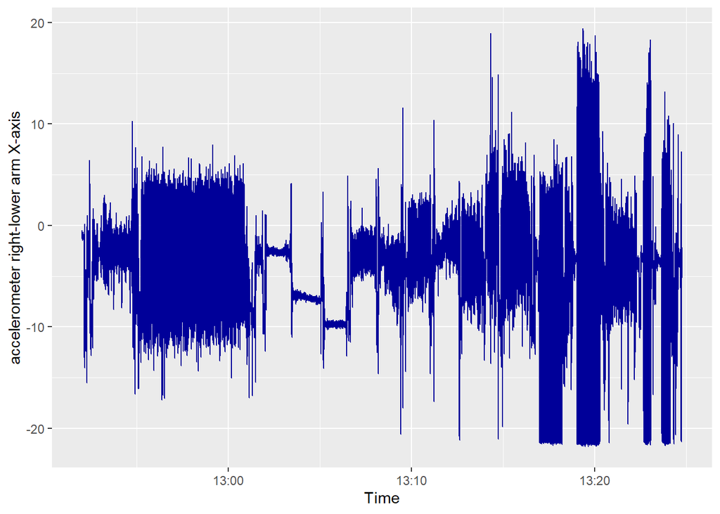

```r
ggplot(data=df_tbl_ts1_srtd, aes(x=date_time,y= acc_rlarm_X))+
  geom_line(colour="#000099")+
  xlab("Time")+ ylab("accelerometer right-lower arm X-axis")
```

#### 3. ECG lead 2

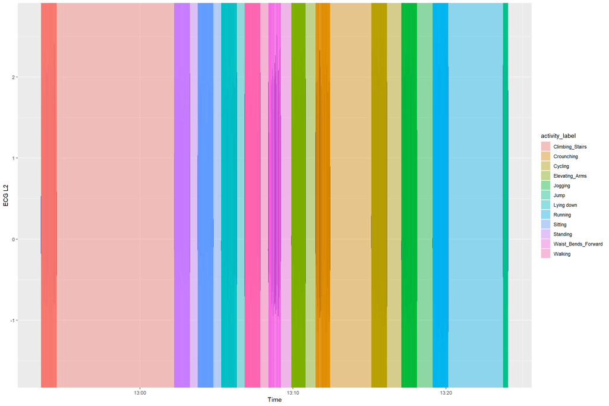

```r
ggplot(data=df_tbl_ts2, aes(x=date_time,y= ecg_l2, fill=activity_label))+
  geom_line(colour="#000099")+
  geom_rect( aes(xmin = date_time, xmax =dplyr::lead(date_time),ymin=-Inf,ymax=Inf), alpha=0.4)+
  xlab("Time")+ ylab("ECG L2")
```

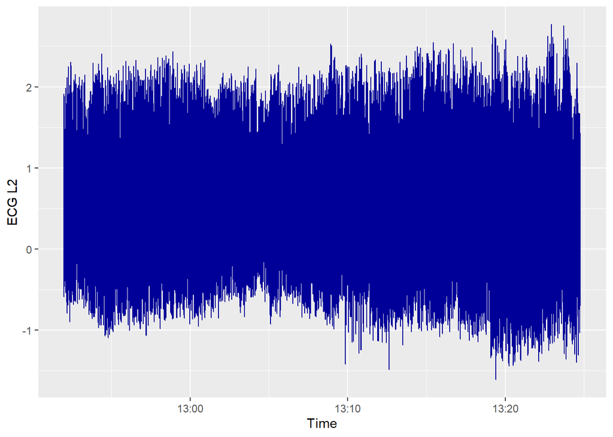

```r
ggplot(data=df_tbl_ts1_srtd, aes(x=date_time,y= ecg_l2))+
  geom_line(colour="#000099")+
  xlab("Time")+ ylab("ECG L2")
```

#### 4. gyroscope on left ankle

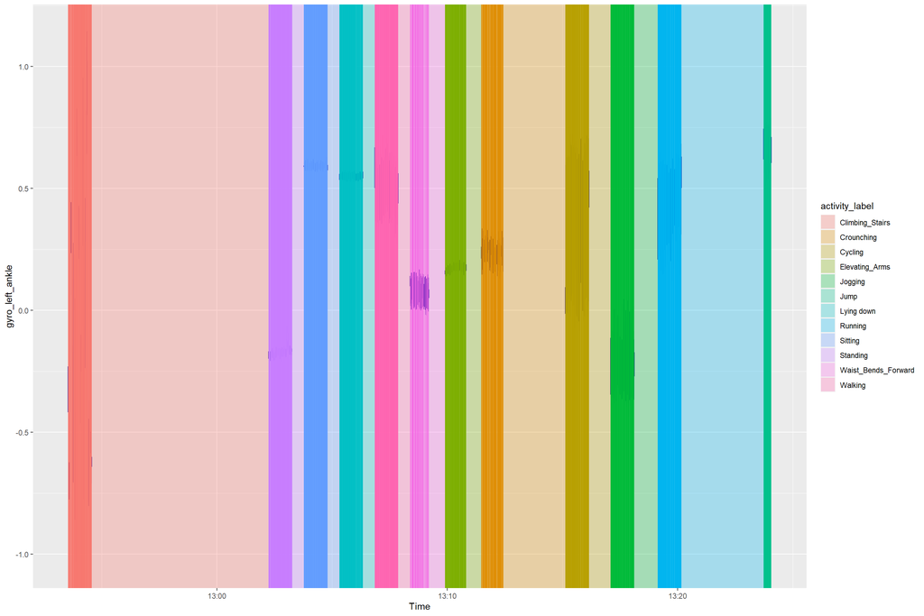

```r
ggplot(data=df_tbl_ts2, aes(x=date_time,y= gyro_leftankle_X, fill=activity_label))+
  geom_line(colour="#000099")+
  geom_rect( aes(xmin = date_time, xmax =dplyr::lead(date_time),ymin=-Inf,ymax=Inf), alpha=0.3)+
  xlab("Time")+ ylab("gyro_left_ankle")
```

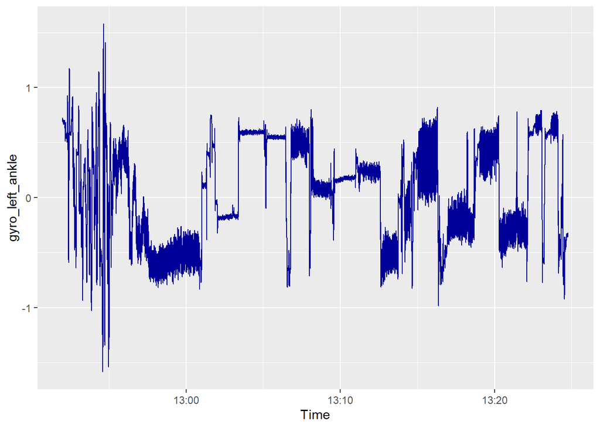

```r
ggplot(data=df_tbl_ts1_srtd, aes(x=date_time,y= gyro_leftankle_X))+
  geom_line(colour="#000099")+
  xlab("Time")+ ylab("gyro_left_ankle")
```

#### Analyzing pair plots of acceleration of chest sensors in all axis

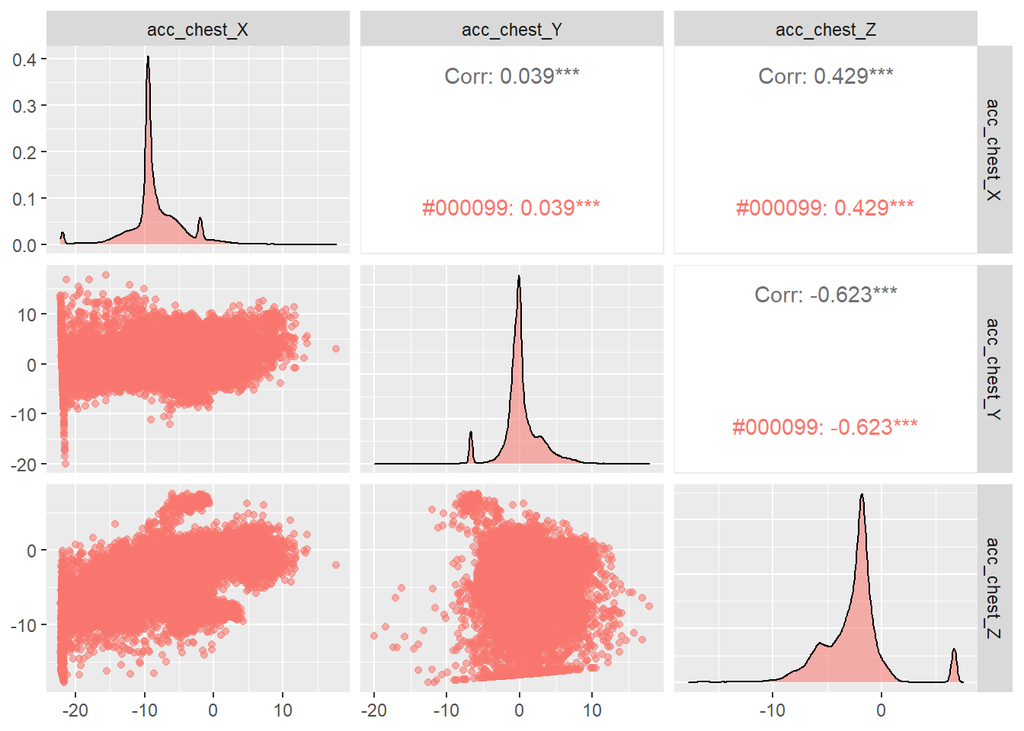

```r
df_tbl_ts1_lbld %>% ggpairs(columns = 1:3, aes(colour="#000099" ,alpha =0.5))
```

#### Analyzing pair plots of gyroscope of left ankle in all axis

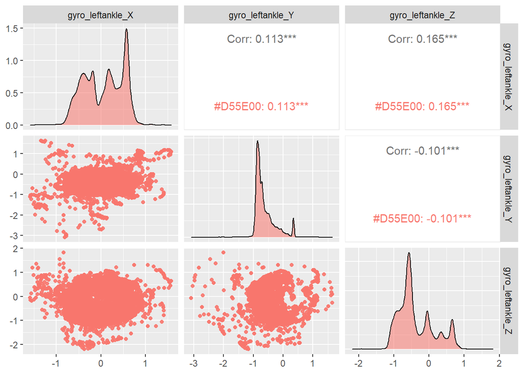

```r
df_tbl_ts1_lbld %>% ggpairs(columns = 9:11, aes(colour="#D55E00" ,alpha =0.5))
```

#### Analyzing pair plots of magnetometer of left ankle in all axis

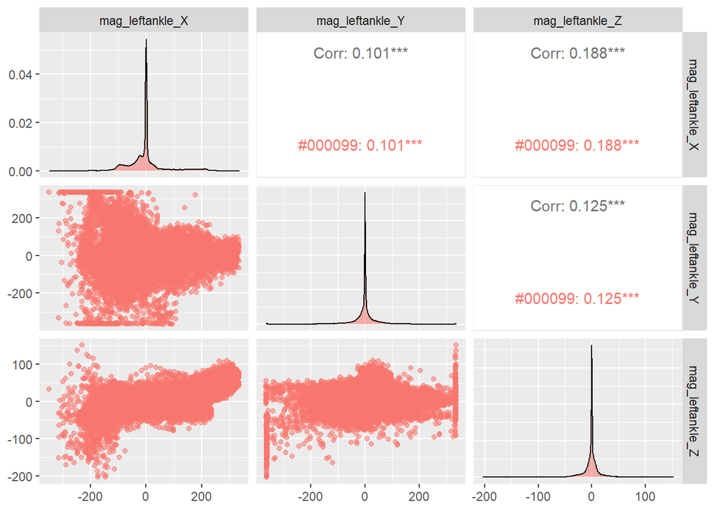

```r
df_tbl_ts1_lbld %>% ggpairs(columns = 12:14, aes(colour="#000099" ,alpha =0.5))
```

#### Analyzing pair plots of ECG in all axis

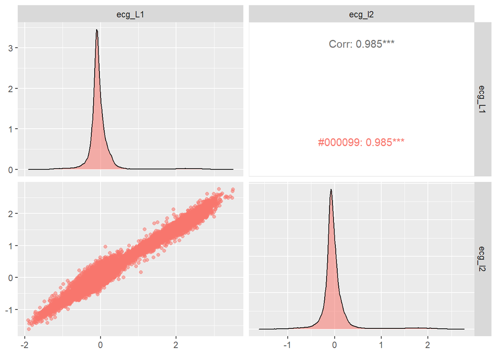

```r
df_tbl_ts1_lbld %>% ggpairs(columns = 4:5, aes(colour="#000099" ,alpha =0.5))
```

The ecg sensors show a direct correlation between them as they are both recording heart beats it makes sense for them to be correlated.

#### Pair plot between accelerometers on chest, ankle and arm along the x-axis:

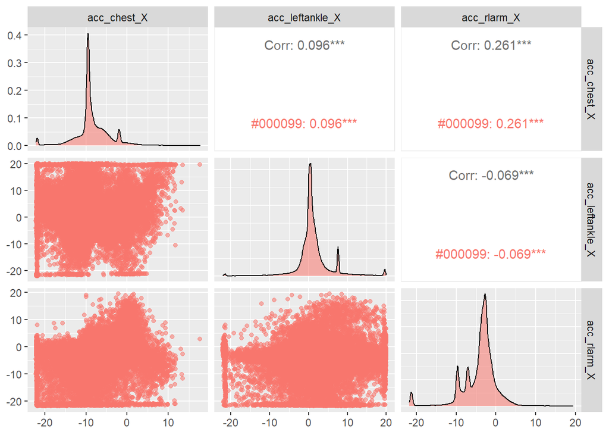

```r
df_tbl_ts1_lbld %>% ggpairs(columns = c(1,6,15), aes(colour="#000099" ,alpha =0.5))
```

This combination has not yielded any significant correaltions

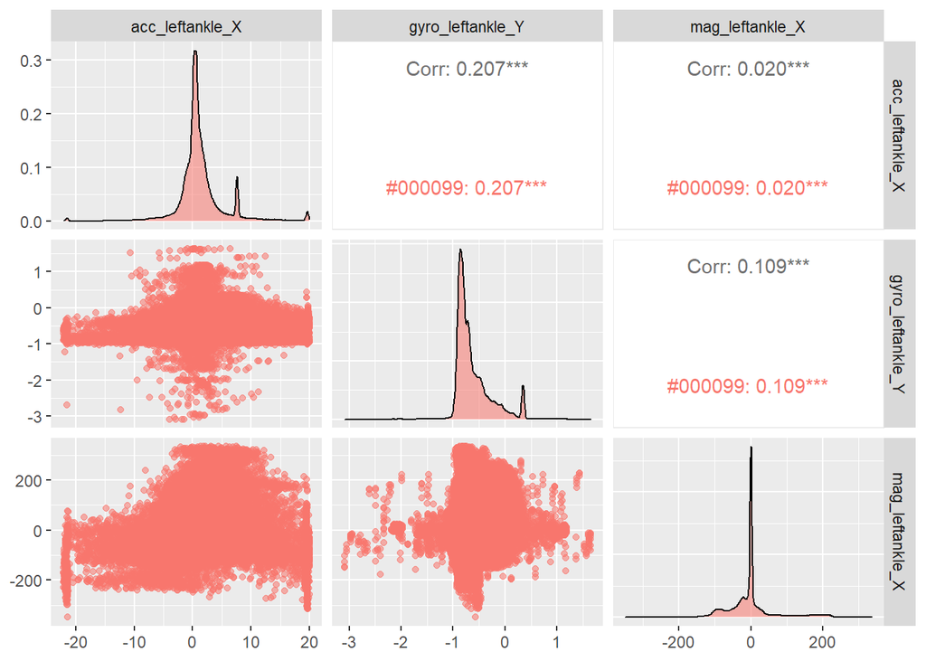

```r
df_tbl_ts1_lbld %>% ggpairs(columns = c(6,10,12), aes(colour="#000099" ,alpha =0.5))
```

#### Principal component analysis:

```r
library(plotly)
library(ggfortify)
#dropping activity, date_time, activity_label

df_tbl_ts1_drpdcol <- df_tbl_ts1_lbld[,-c(4,24,25,26)]

pca <- prcomp(df_tbl_ts1_drpdcol, scale=TRUE)
```

```r
#autoplot(pca, data=df_tbl_ts1_lbld, colour='activity_label')
```

```r
#pca_plot <- autoplot(pca, data=df_tbl_ts1_lbld, colour='activity_label')

#pca_plot
```

#### Biplot from the PCA

```r
#pca_plot_loadings <- autoplot(pca, data=df_tbl_ts1_lbld, colour='activity_label',
                              #loadings=TRUE, loadings.label = TRUE,
                              #loadings.label.size=3)
#pca_plot_loadings
```

```r
head(pca)
```

```
## $sdev
##  [1] 1.8629693 1.5109970 1.3937410 1.2550929 1.1981394 1.1544512 1.0928731
##  [8] 1.0101338 1.0043591 0.9838685 0.8978060 0.8824575 0.8400267 0.8058465
## [15] 0.7882371 0.7480646 0.6746892 0.6062021 0.5559616 0.4780940 0.4126836
## [22] 0.3424755
##
## $rotation
##                           PC1         PC2          PC3         PC4         PC5
## acc_chest_X       0.206367874 -0.16030006  0.291328257 -0.27864805  0.34127412
## acc_chest_Y      -0.342287392  0.11516416  0.207571783 -0.06183819  0.01460592
## acc_chest_Z       0.411700612 -0.19110507 -0.002615619 -0.02732116  0.20915341
## ecg_l2           -0.010692549 -0.01749159 -0.007343808 -0.01349573  0.01157253
## acc_leftankle_X   0.159051178 -0.09124434 -0.105515064 -0.21918821 -0.19213301
## acc_leftankle_Y   0.298345934 -0.06266895  0.088475795 -0.26867752  0.17017130
## acc_leftankle_Z   0.101161984  0.11345744 -0.029426284  0.42879556  0.37376691
```

[output cut: 22868 more lines]

```r
summary(pca)
```

```
## Importance of components:
##                           PC1    PC2    PC3    PC4     PC5     PC6     PC7
## Standard deviation     1.8630 1.5110 1.3937 1.2551 1.19814 1.15445 1.09287
## Proportion of Variance 0.1578 0.1038 0.0883 0.0716 0.06525 0.06058 0.05429
## Cumulative Proportion  0.1578 0.2615 0.3498 0.4214 0.48669 0.54727 0.60155
##                            PC8     PC9   PC10    PC11   PC12    PC13    PC14
## Standard deviation     1.01013 1.00436 0.9839 0.89781 0.8825 0.84003 0.80585
## Proportion of Variance 0.04638 0.04585 0.0440 0.03664 0.0354 0.03207 0.02952
## Cumulative Proportion  0.64794 0.69379 0.7378 0.77443 0.8098 0.84190 0.87142
##                           PC15    PC16    PC17   PC18    PC19    PC20    PC21
## Standard deviation     0.78824 0.74806 0.67469 0.6062 0.55596 0.47809 0.41268
## Proportion of Variance 0.02824 0.02544 0.02069 0.0167 0.01405 0.01039 0.00774
## Cumulative Proportion  0.89966 0.92509 0.94578 0.9625 0.97654 0.98693 0.99467
##                           PC22
## Standard deviation     0.34248
## Proportion of Variance 0.00533
## Cumulative Proportion  1.00000
```

```r
#barplot(pca.var.per, xlab='Principle Components', ylab='Percent Variance', names.arg=1:length(pca.var.per),
        #las=1, ylim=c(0, max(pca.var.per)), col='gray')

#abline(h=1/ncol(df_tbl_ts1_drpdcol)*100, col='red')
```